# Time Series Unit 3

Sean Kennedy

1/18/2020

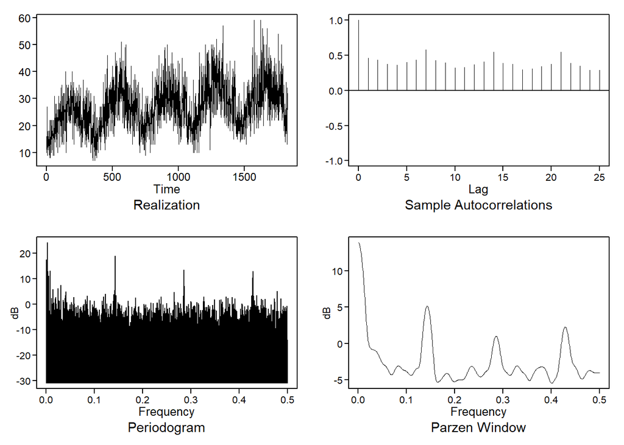

[output not shown]

[output cut: 545 more lines]

```r
walmart_data = read.csv('Walmart.csv')
item8 = walmart_data %>% filter(item == 1 & store==8)
plotts.sample.wge(item8$sales)
```

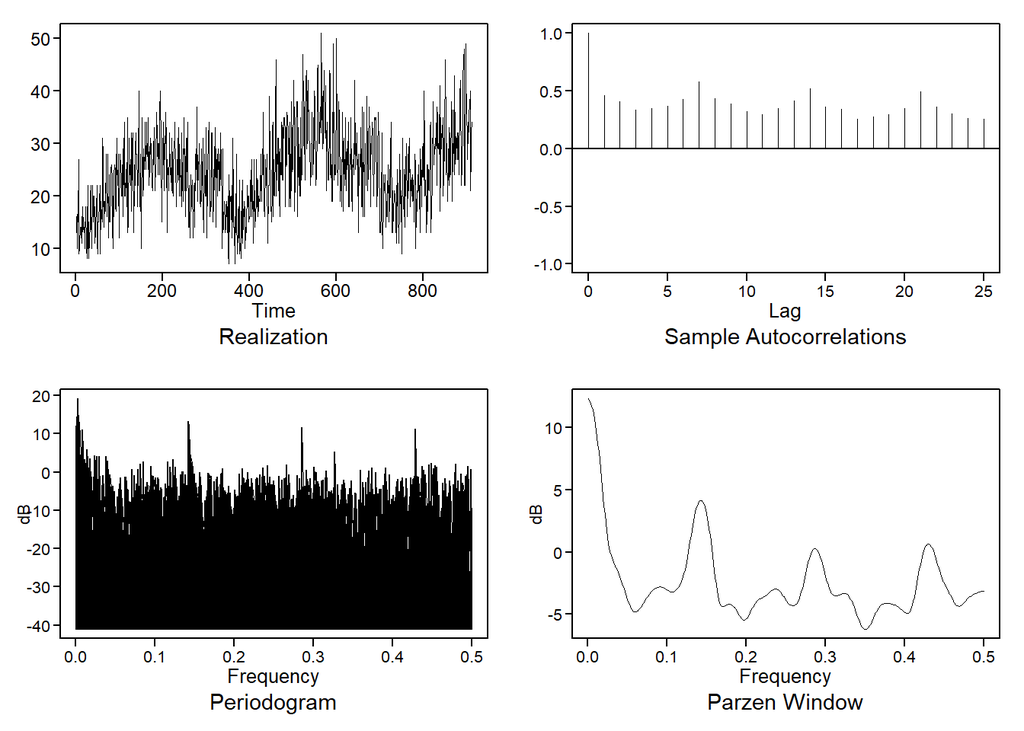

[output not shown]

[output cut: 272 more lines]

```r
plotts.sample.wge(item8$sales[0:913])
```

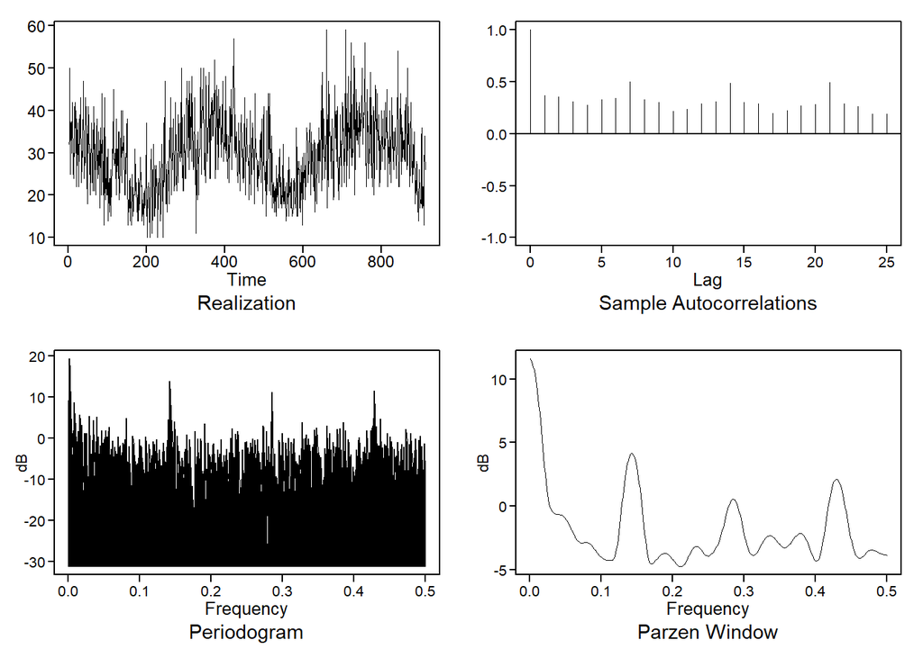

[output not shown]

[output cut: 272 more lines]

```r
plotts.sample.wge(item8$sales[914:1826])
```

### Questions:

- Does the data come from a stationary process?
- Does the mean depend on time?
  - There is a seasonal/cyclical component to the data, but there also appears to be a drift in the mean upward.
- Constant variance?
  - without analyzing another realization, we cannot make any definitive statements on the variance
- Autocrrelation structure:
  - Autocorrelation structure appear to be constant for the time windows sampled (i.e do not depend on time, only lag)
- Evidence of yearly/weekly seasonality?
  - yearly: yes, it appears that there are spikes in the monthly data spectral density at 0.083 which would correspond to a periodicity of 12 (1/0.083)
  - weekly: yes, there is a spike in the weekly spectral density around 0.02 which would correspond to a frquency of 52 weeks (1/~0.02)

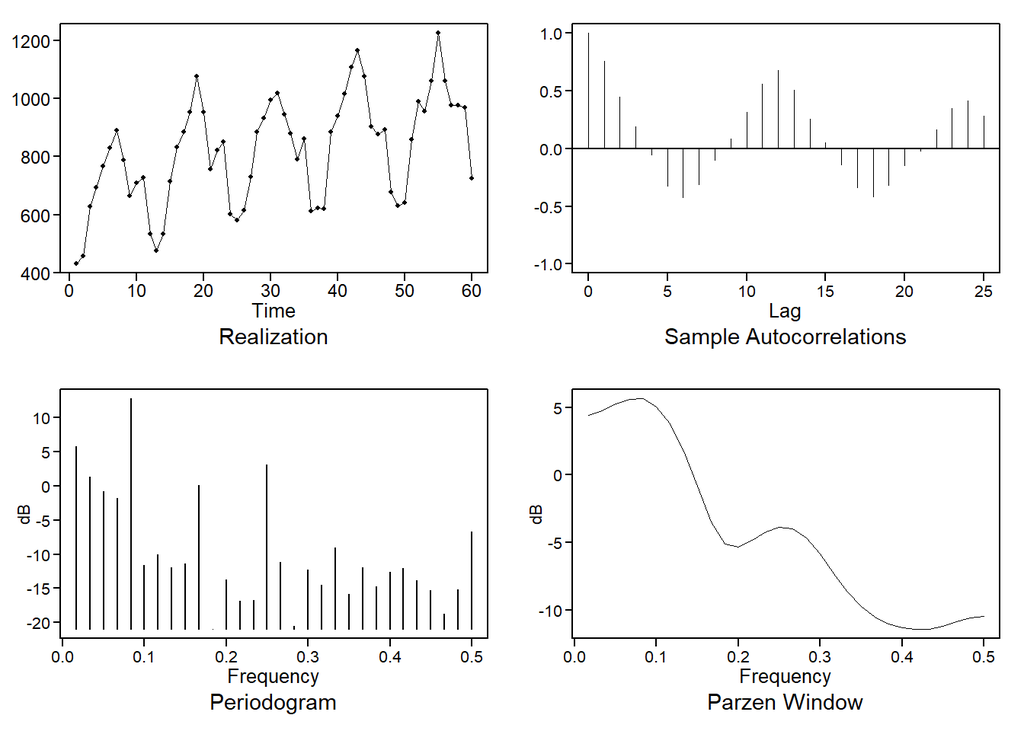

[output not shown]

```r
item8$date = as.Date(item8$date, format='%m/%d/%Y')
item8_by_month = item8 %>% group_by(month=floor_date(date, 'month')) %>% summarize(monthly_sales=sum(sales))

plotts.sample.wge(item8_by_month$monthly_sales)
```

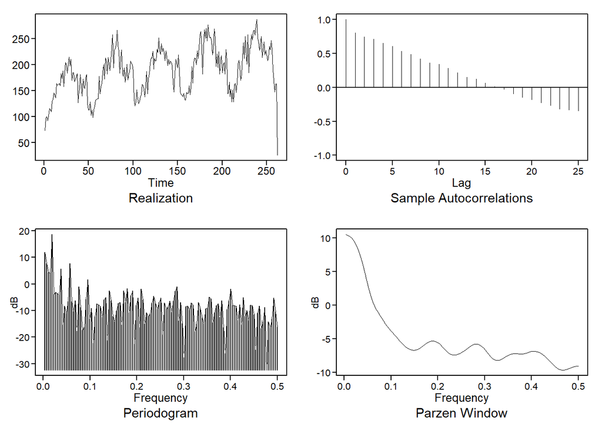

[output not shown]

[output cut: 69 more lines]

```r
item8_by_week = item8 %>% group_by(month=floor_date(date, 'week')) %>% summarize(weekly_sales=sum(sales))

plotts.sample.wge(item8_by_week$weekly_sales)
```

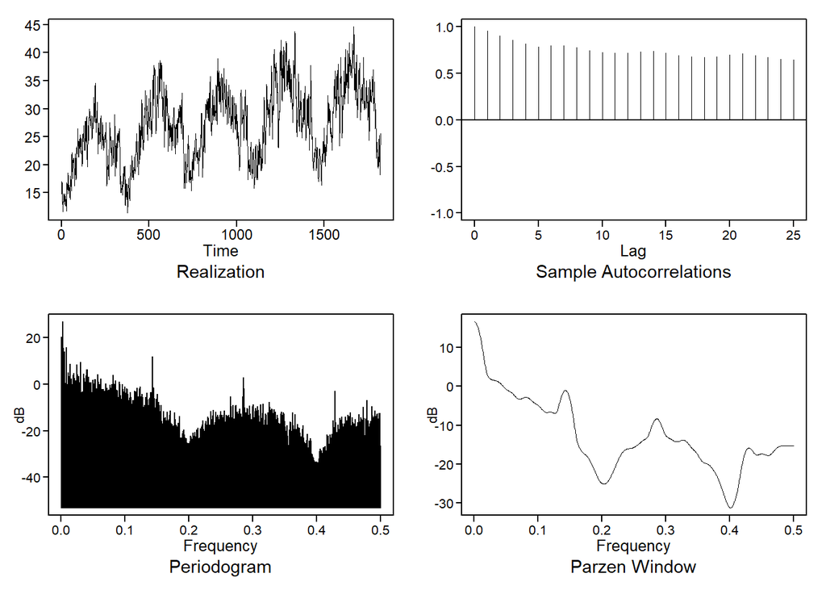

[output not shown]

[output cut: 545 more lines]

```r
ma5 = stats::filter(item8$sales, rep(1,5))/5
plotts.sample.wge(ma5[!is.na(ma5)])
```

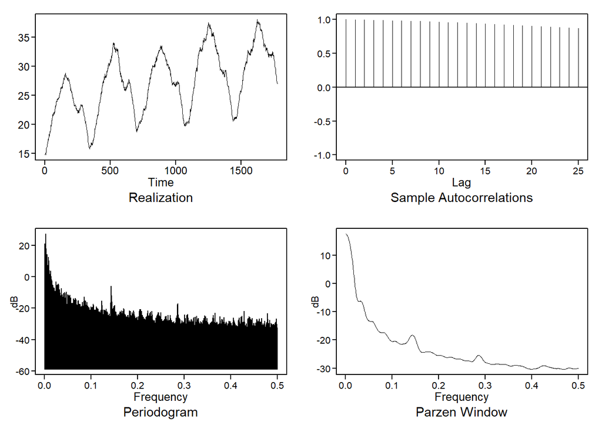

[output not shown]

[output cut: 500 more lines]

```r
ma51 = stats::filter(item8$sales, rep(1,51))/51
plotts.sample.wge(ma51[!is.na(ma51)])
```

### TAKEAWAY 1 HIGH PASS FILTERING

- ISOLATES HIGHER FREQUENCY SIGNALS
- DIFFERENCNG OPERATIONS

### TAKEAWAY 2 LOW PASS FILTERING

- ISOLATES LOWER FREQUENCY SIGNALS
- SMOOTHING/MA ETC OPERATIONS

### TAKEAWAY 3 (Question?)

```
  Why do we allow MA calcs to be window centered in the examples in the videos? Doesn't this cause information leakage? Is it allowed because we are only looking to build a model that describes the trend and not a predictive model?
```

```r
Realization = gen.sigplusnoise.wge(200,coef = c(5,0),freq = c(.1,0), vara = 10, sn = 1)
```

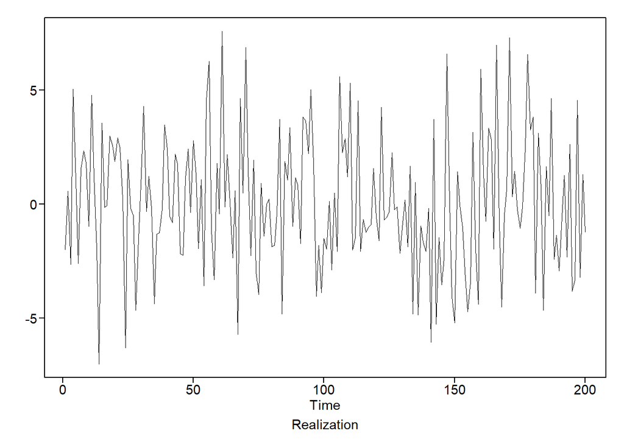

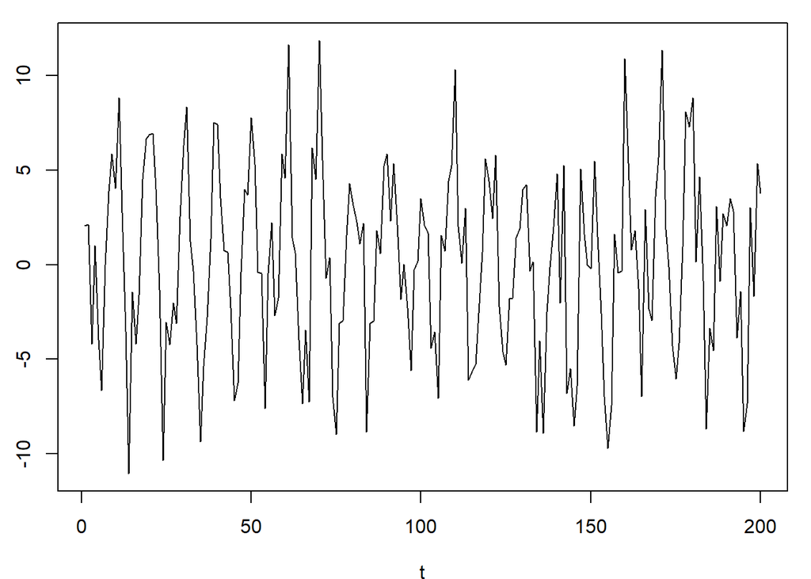

### TAKEAWY 4 GLP (General Linear Process)

### AR1

```
This model is a probabilty(?) weighted sum of 3 terms:

  - Beta: The conribution to the term from the moving(?) average (mu) = (1-phi)*mu

  - Phi: Coefficient of martingale assumption (i.e weighting on lag(1) term)

  - a: random noise
```

## Phi Negative

- cyclical behavior, spike in PSD at 0.5, sinusodial ACF (larger the abs of phi, quicker decay)